# Exploring zeta-diversity

indra deCastro

25 mayo, 2018

### References for zeta diversity

- [R package publication 17 may 2018!](https://www.biorxiv.org/content/biorxiv/early/2018/05/17/324897.full.pdf)
- [R package manual](https://cran.r-project.org/web/packages/zetadiv/zetadiv.pdf)
- [Personal web of the author](https://melodiemcgeoch.com/zeta-diversity/)
- Original paper: [Hui C. & McGeoch M. A. (2014)](http://www.jstor.org/stable/pdf/10.1086/678125.pdf?refreqid=excelsior%3A14d55e03e6facc9931e9115e5c585530) Zeta Diversity as a Concept and Metric That Unifies Incidence-Based Biodiversity Patterns. Am. Nat. 184, 684-94.
- [McGeogch *et al.* 2017](https://www.biorxiv.org/content/biorxiv/early/2017/11/09/216580.full.pdf), The application of zeta diversity as a continuous measure of compositional change in ecology. bioRxiv.

### Highlights by authors (Latombe *et al.* 2018)

- Zeta diversity is the mean number of species shared by any number of assemblages
- Zeta diversity captures all diversity components produced by assemblage partitioning biodiversity
- Analyses relate zeta diversity to space, environment and spatial scale
- Analyses differentiate the contribution of rare and common species to biodiversity

### Our concerns (deCastro-Arrazola *et al.* 2018)

- it DOES NOT consider abundances!!! Can’t compare with Bray-Curtis dissimilarities.
- totally new framework, would require a complete change of point of view of the manuscript
- manuscript already includes too many analytical tools, adding would make the publication complicated.

### Design a function to read datasets of four campaingns and converting abundance into incidence

(zeta-diversity can’t handle abundance data)

```r
read.and.pa <- function(data.path) {
  raw <- read.table(data.path, header=T, sep=",")
  rownames(raw) <- raw$sites
  raw$sites <- NULL
  decostand(raw, "pa")
}
```

### Read data

```r
adry13 <- read.and.pa("adry13.csv")
adry14 <- read.and.pa("adry14.csv")
awet13 <- read.and.pa("awet13.csv")
awet14 <- read.and.pa("awet14.csv")
```

### Calculate zeta diversity and visually explore patterns

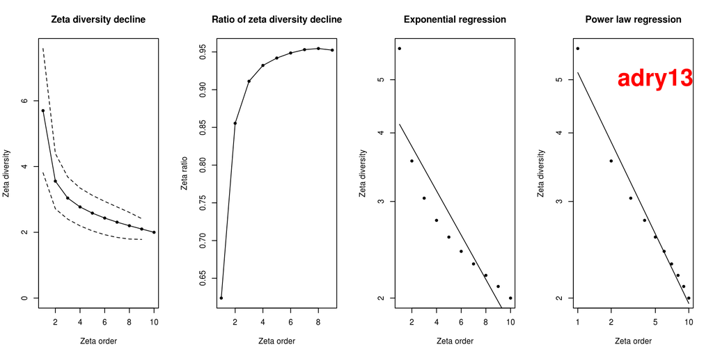

```r
Plot.zeta.decline(Zeta.decline.ex(adry13, orders = 1:10))
text(5, 5, "adry13", cex=3, font=2, col="red")
```

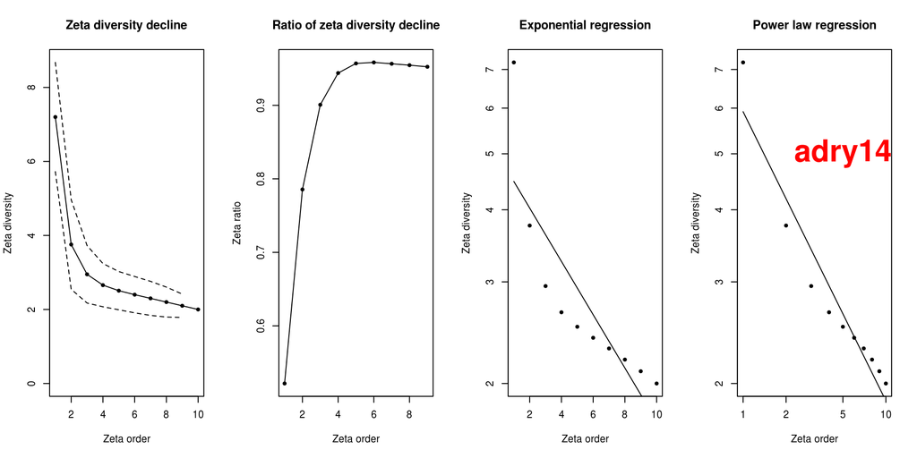

```r
Plot.zeta.decline(Zeta.decline.ex(adry14, orders = 1:10))
text(5, 5, "adry14", cex=3, font=2, col="red")
```

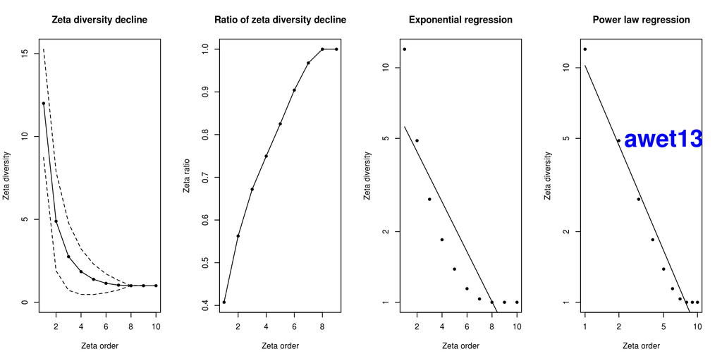

```r
Plot.zeta.decline(Zeta.decline.ex(awet13, orders = 1:10))
text(5, 5, "awet13", cex=3, font=2, col="blue")
```

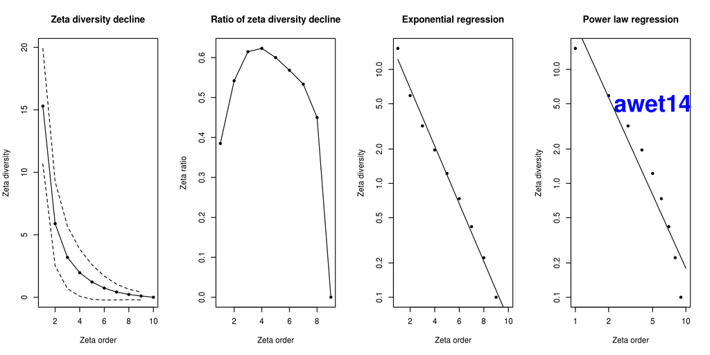

```r
Plot.zeta.decline(Zeta.decline.ex(awet14, orders = 1:10))
text(5, 5, "awet14", cex=3, font=2, col="blue")
```

### Read coordinates data

```r
points <- read.table("/home/indra/Documents/2013scarabs/publications/20160601.c3.sahara.tax/tables.and.figures/f1.map/dat.20140724.aridity.at.replicas.csv", header=T, dec=".")
replicate.coords <- points[, c("LONGITUD", "LATITUD")]
replicate.coords$point <- as.numeric(gsub("mor.|A|B", "", points$replicas))

library(plyr)
mor.sites <- ddply(replicate.coords, .(point), summarize,
      "x" = mean(LONGITUD),
      "y" = mean(LATITUD))
mor.coords <- mor.sites[,c("x","y")]
```

### Distance decay at a all orders of zeta

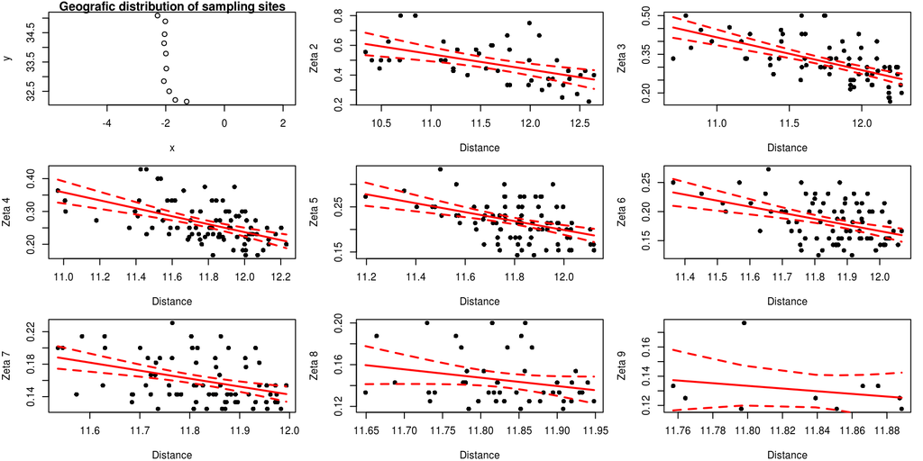

```r
par(mfrow=c(3,3), mar=c(4,4,1,1))
plot(mor.coords, main="Geografic distribution of sampling sites", asp=1)

orders <- 2:9
invisible(lapply(orders, function(order){
      Zeta.ddecay(mor.coords*100000, adry13, sam = 100, order = order, method.glm = "glm.fit2", confint.level = 0.95, trsf = "log", normalize = "Jaccard")
      }))
```

### Distance decay slopes

```
## [1] 2
## [1] 3
## [1] 4
## [1] 5
## [1] 6
## [1] 7
## [1] 8
## [1] 9
```

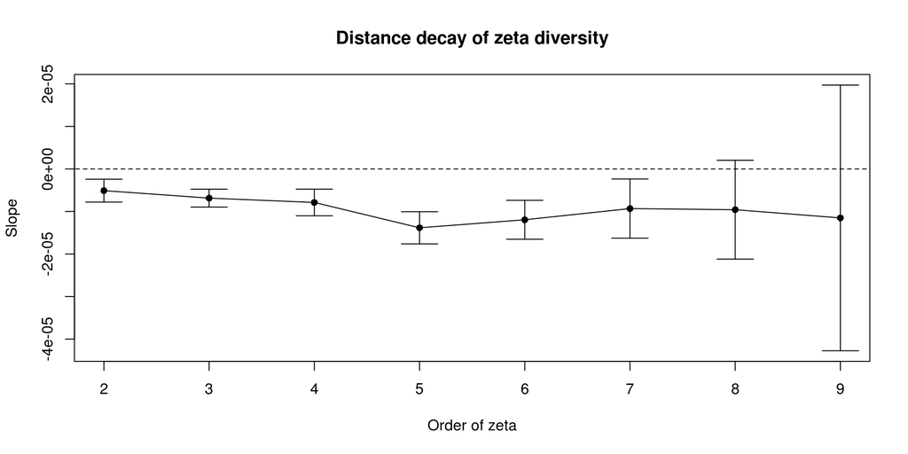

```r
zeta.ddecays.marion <- Zeta.ddecays(mor.coords*100000, adry13, sam = 100,
   orders = orders, plot = TRUE, confint.level = 0.95)
```